# report

# Временной ряд

```r
library(forecast)
library(tseries)
library(Hmisc)
data <- read.csv("./Raspisanie_Russia.csv", header = TRUE, sep = ";")
data$Average.daily <- NULL
names(data)
```

```
## [1] "Datetime" "Monthly"
```

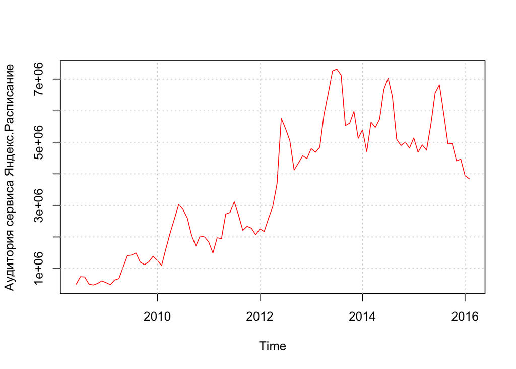

```r
xname <- "Аудитория сервиса Яндекс.Расписание"

data$Monthly <- as.numeric(data$Monthly)
data$Datetime <- as.Date(as.yearmon(data$Datetime, format="%Y-%m-%d"))
start <- as.numeric(c(format(data$Datetime[1], "%Y"), format(data$Datetime[1], "%m")))
end <- as.numeric(c(format(tail(data$Datetime, n=1), "%Y"), format(tail(data$Datetime, n=1), "%m")))

tSeries <- ts(data = data$Monthly, start = start, end = end, frequency = 12)

plot(tSeries, type="l", ylab=xname, col="red")
grid()
```

Попробуем поделить на число дней в месяце:

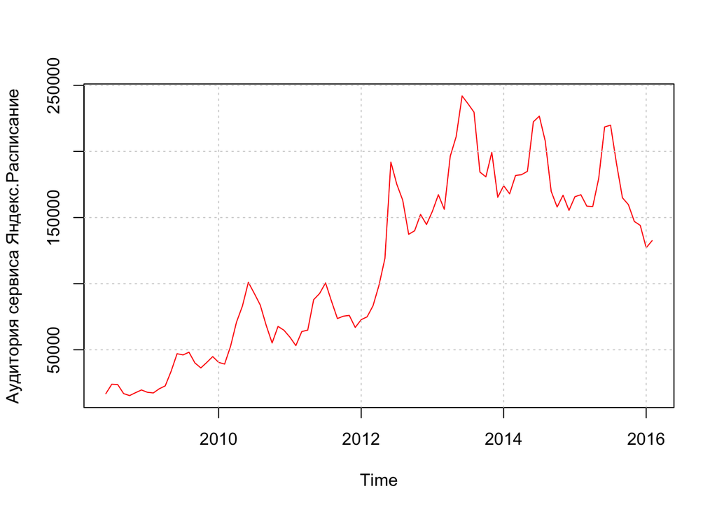

```r
plot(tSeries / monthDays(as.Date(time(tSeries))), type="l", ylab=xname, col="red")
grid()
```

Ряд не стал более регулярным, так что вернёмся к исходным данным.

STL-декомпозиция ряда:

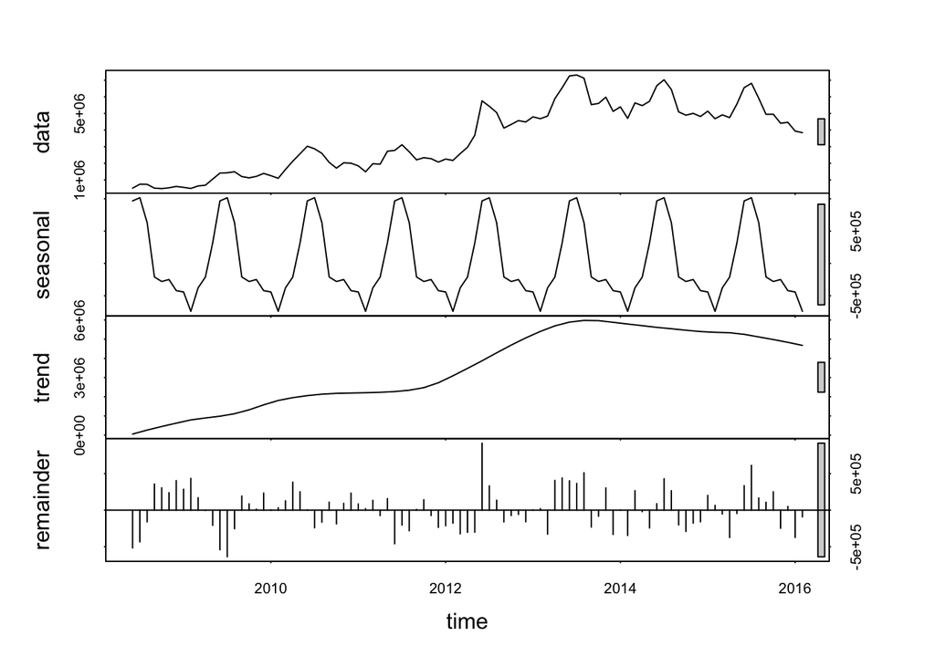

```r
plot(stl(tSeries, s.window="periodic"))
```

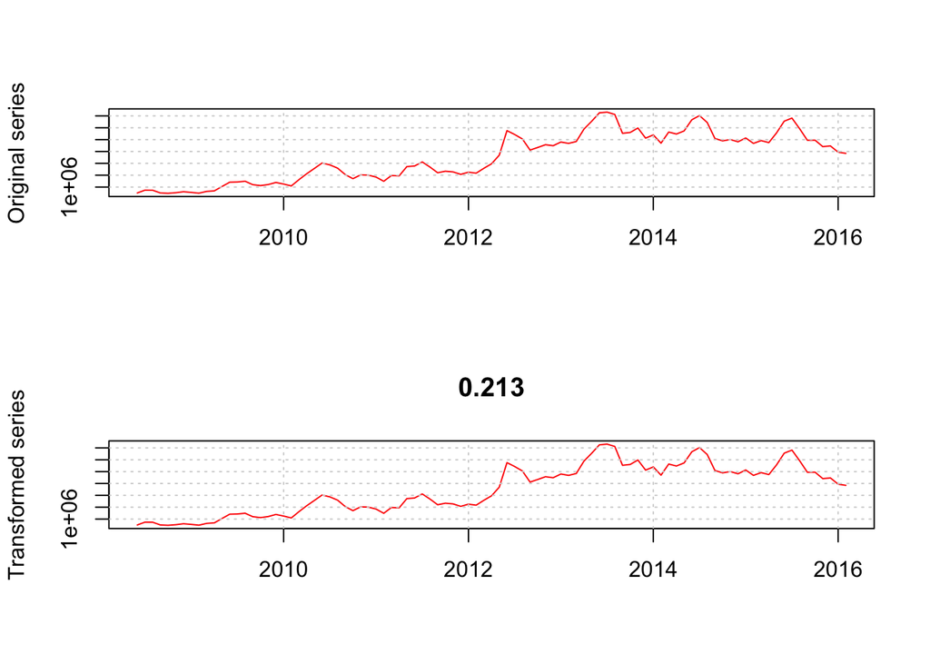

```r
par(mfrow=c(2,1))
plot(tSeries, ylab="Original series", xlab="", col="red")
grid()

LambdaOpt <- BoxCox.lambda(tSeries)
plot(BoxCox(tSeries, 1), ylab="Transformed series", xlab="", col="red")
title(main=toString(round(LambdaOpt, 3)))
grid()
```

```r
LambdaOpt <- 1
```

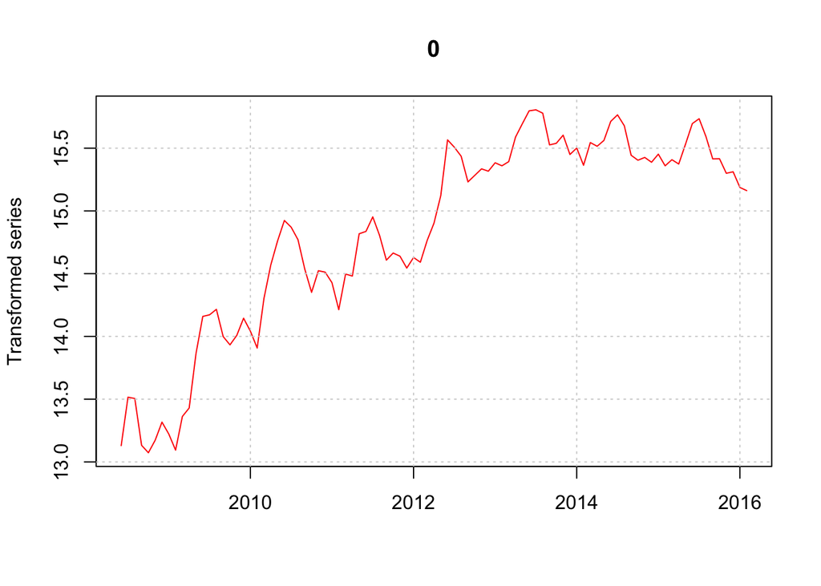

```r
plot(BoxCox(tSeries, 0), ylab="Transformed series", xlab="", col="red")
title(main="0")
grid()
```

# Ручная ARIMA

## Стационаризация ряда

Исходный ряд нестационарен (p<0.01, критерий KPSS); сделаем сезонное дифференцирование:

```r
kpss.test(BoxCox(tSeries, LambdaOpt))
```

```
##
##  KPSS Test for Level Stationarity
##
## data:  BoxCox(tSeries, LambdaOpt)
## KPSS Level = 2.6418, Truncation lag parameter = 2, p-value = 0.01
```

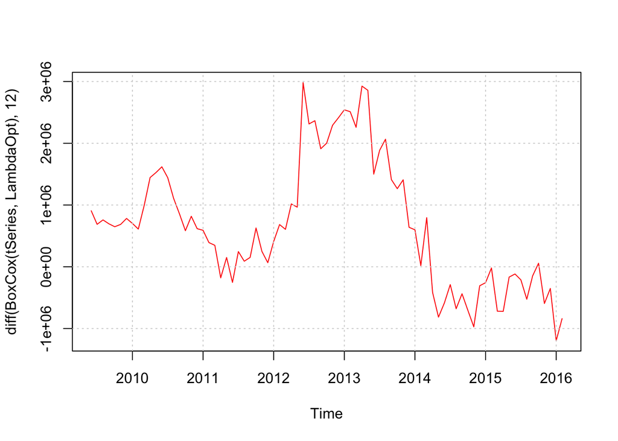

```r
plot(diff(BoxCox(tSeries, LambdaOpt), 12), type="l", col="red")
grid()
```

Ряд всё ещё нестационарен (p<0.0121653, критерий KPSS). Проведём ещё одно дифференцирование:

```r
kpss.test(diff(BoxCox(tSeries, LambdaOpt), 12))
```

```
##
##  KPSS Test for Level Stationarity
##
## data:  diff(BoxCox(tSeries, LambdaOpt), 12)
## KPSS Level = 0.71518, Truncation lag parameter = 2, p-value =
## 0.01217
```

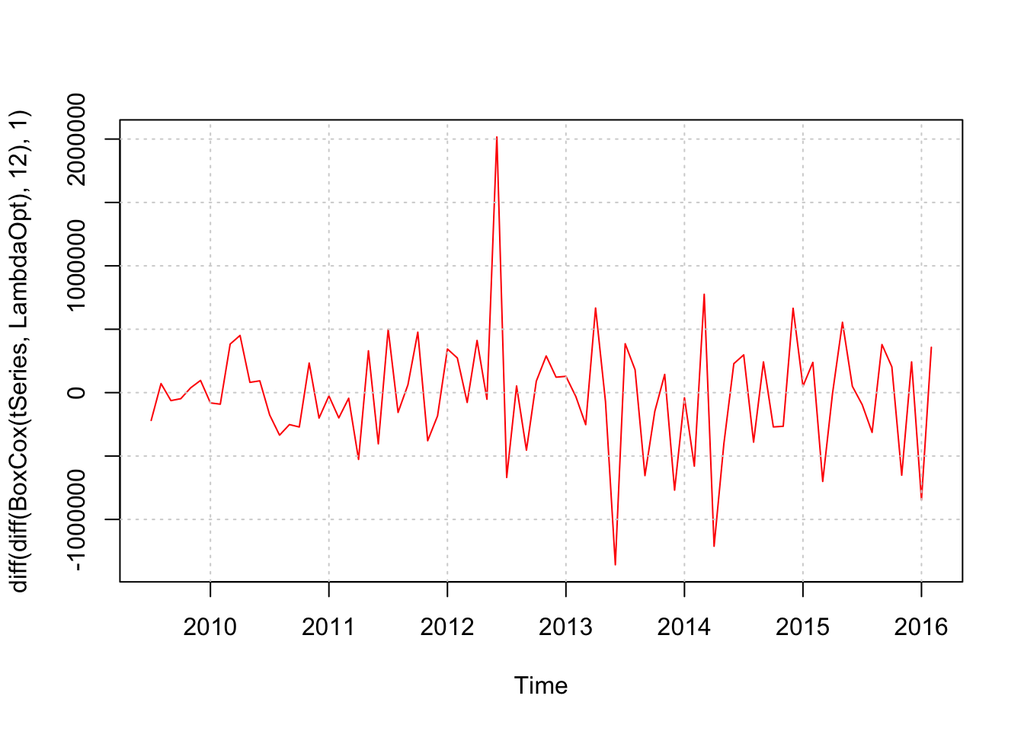

```r
plot(diff(diff(BoxCox(tSeries, LambdaOpt), 12), 1), type="l", col="red")
grid()
```

```r
kpss.test(diff(diff(BoxCox(tSeries, LambdaOpt), 12), 1))
```

```
##
##  KPSS Test for Level Stationarity
##
## data:  diff(diff(BoxCox(tSeries, LambdaOpt), 12), 1)
## KPSS Level = 0.12415, Truncation lag parameter = 2, p-value = 0.1
```

Для полученного ряда гипотеза стационарности не отвергается (p>0.1)

Посмотрим на ACF и PACF полученного продифференцированного ряда:

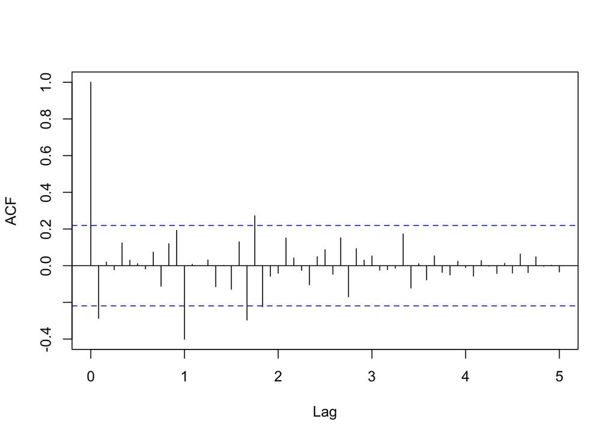

```r
# par(mfrow=c(2,1))
acf(diff(diff(BoxCox(tSeries, LambdaOpt), 12), 1), lag.max=5*12, main="")
```

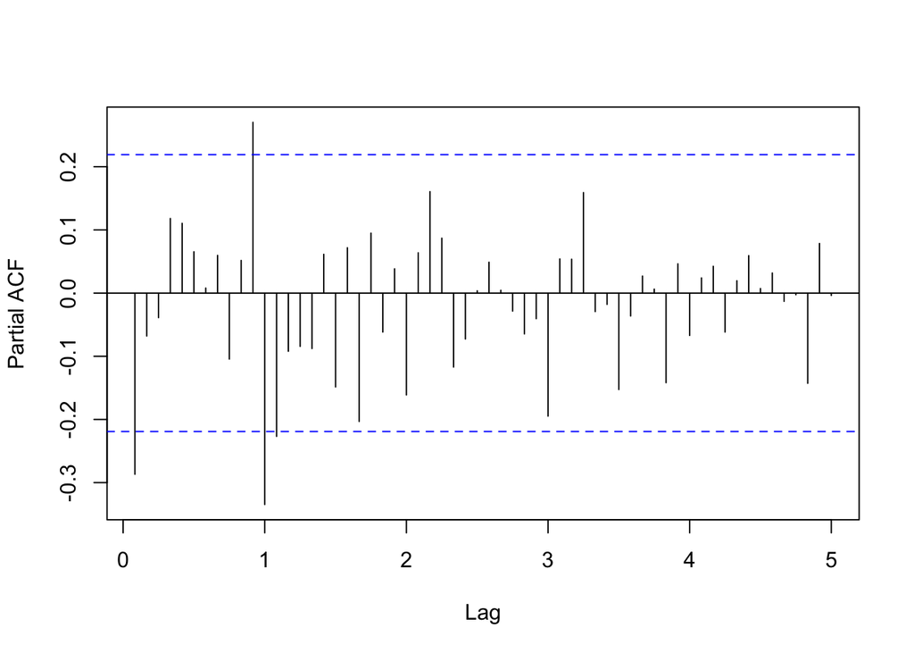

```r
pacf(diff(diff(BoxCox(tSeries, LambdaOpt), 12), 1), lag.max=5*12, main="")
```

ACF - 1, 12. PACF - 1, 12. Ищем вокруг ARIMA(1,1,1)(1,1,1)$_{12}$

```r
?Arima
Arima(tSeries, order=c(1,1,1), seasonal=c(1,1,0), lambda=LambdaOpt)$aicc
```

```
## [1] 2300.501
```

```r
Arima(tSeries, order=c(0,1,0), seasonal=c(0,1,0), lambda=LambdaOpt)$aicc
```

```
## [1] 2315.182
```

```r
Arima(tSeries, order=c(1,1,0), seasonal=c(0,1,0), lambda=LambdaOpt)$aicc
```

```
## [1] 2310.588
```

```r
Arima(tSeries, order=c(1,1,1), seasonal=c(1,1,1), lambda=LambdaOpt)$aicc
```

```
## [1] 2297.362
```

```r
Arima(tSeries, order=c(1,1,2), seasonal=c(1,1,2), lambda=LambdaOpt)$aicc
```

```
## [1] 2301.131
```

```r
Arima(tSeries, order=c(1,1,1), seasonal=c(1,1,2), lambda=LambdaOpt)$aicc
```

```
## [1] 2299.623
```

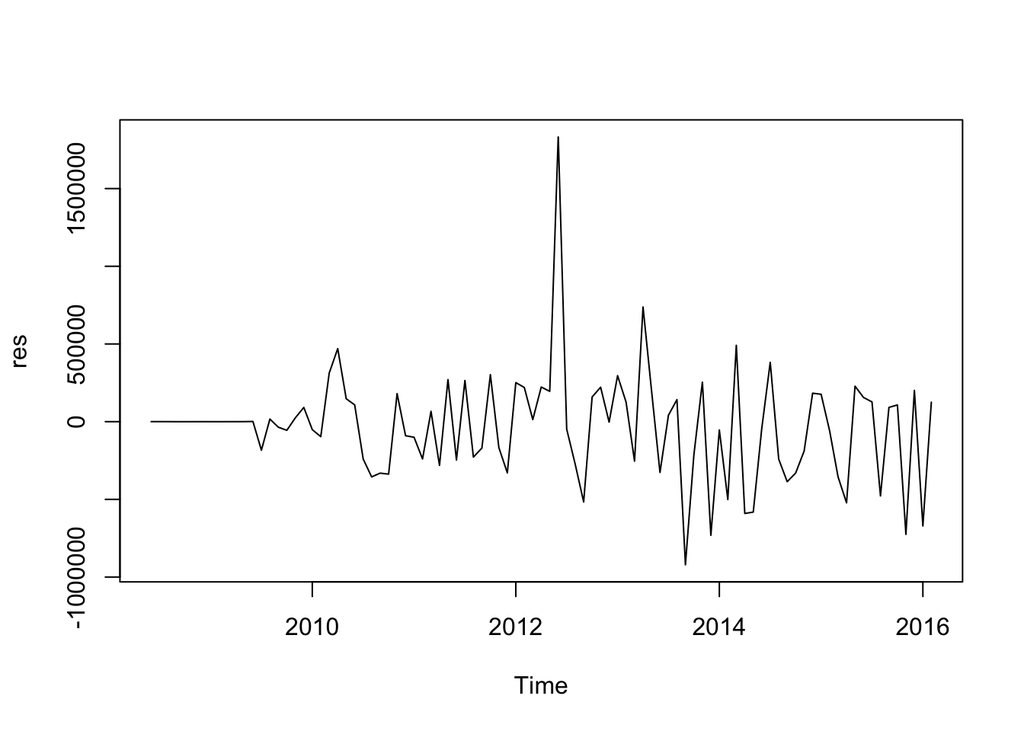

```r
fit.arima.hand <- Arima(tSeries, order=c(1,1,1), seasonal=c(1,1,1), lambda=LambdaOpt)
res <- residuals(fit.arima.hand)
plot(res)
```

Видно, что в начале ряда остатки не определены, что логично, поскольку модель сезонная. Отрежем начало ряда остатков и проанализируем их:

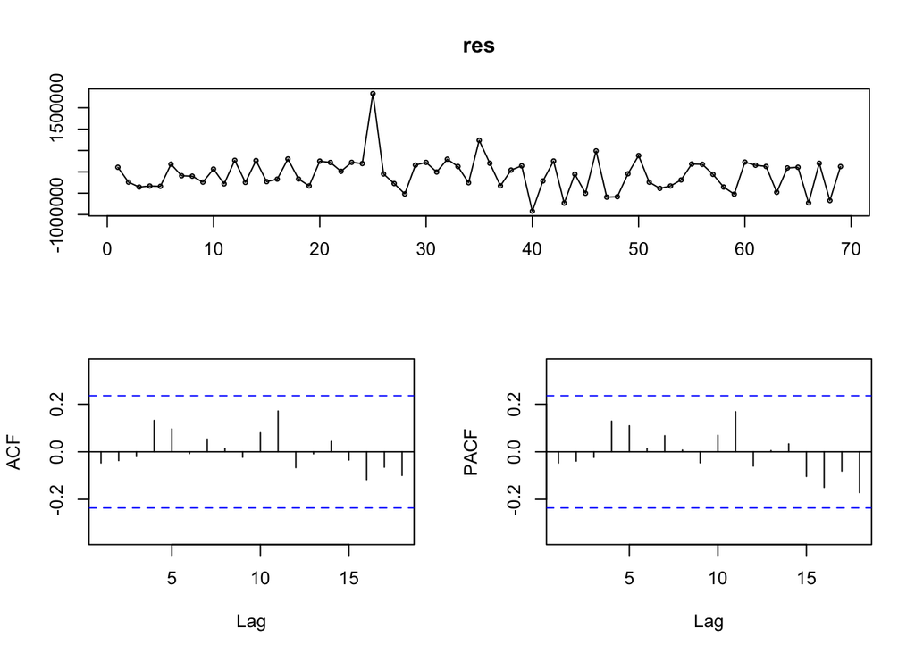

```r
res <- res[-c(1:24)]
tsdisplay(res)
```

Достигаемые уровни значимости критерия Льюнга-Бокса для остатков:

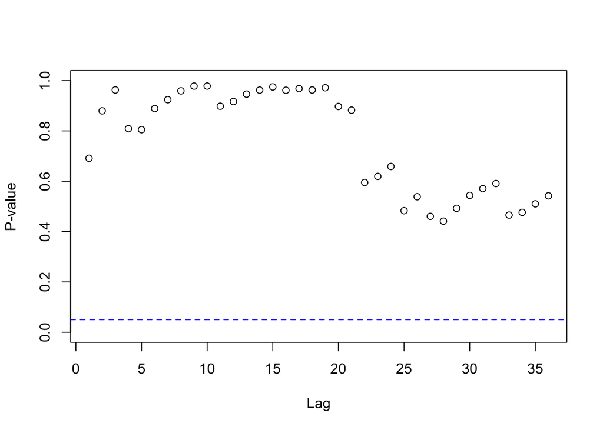

```r
p <- rep(0, 1, frequency(tSeries)*3)
for (i in 1:length(p)){
  p[i] <- Box.test(res, lag=i, type = "Ljung-Box")$p.value
}
plot(p, xlab="Lag", ylab="P-value", ylim=c(0,1))
abline(h = 0.05, lty = 2, col = "blue")
```

Q-Q plot и гистограмма:

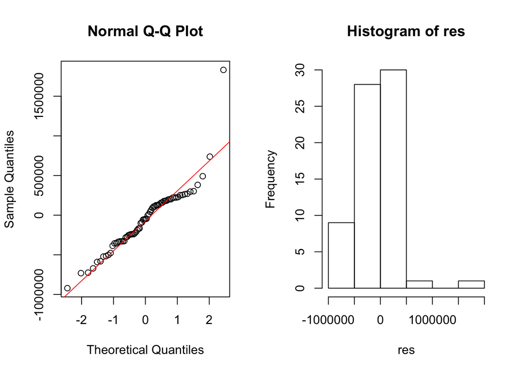

```r
par(mfrow=c(1,2))
qqnorm(res)
qqline(res, col="red")
hist(res)
```

# Автоматическая Arima

```r
fit.arima.auto <- auto.arima(tSeries, lambda=LambdaOpt)
fit.arima.auto
```

```
## Series: tSeries
## ARIMA(0,1,1)(0,1,1)[12]
## Box Cox transformation: lambda= 1
##
## Coefficients:
##           ma1     sma1
##       -0.2209  -0.5804
## s.e.   0.1050   0.1220
##
## sigma^2 estimated as 1.467e+11:  log likelihood=-1143.45
## AIC=2292.91   AICc=2293.22   BIC=2300.05
```

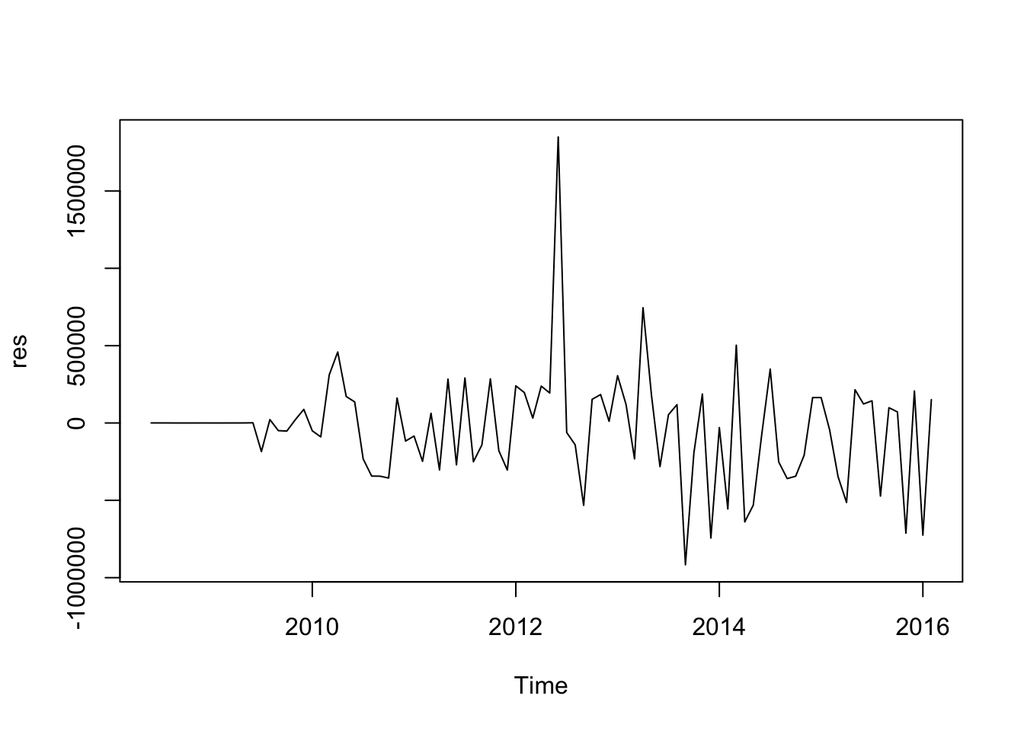

```r
res <- residuals(fit.arima.auto)
plot(res)
```

Достигаемые уровни значимости критерия Льюнга-Бокса для остатков:

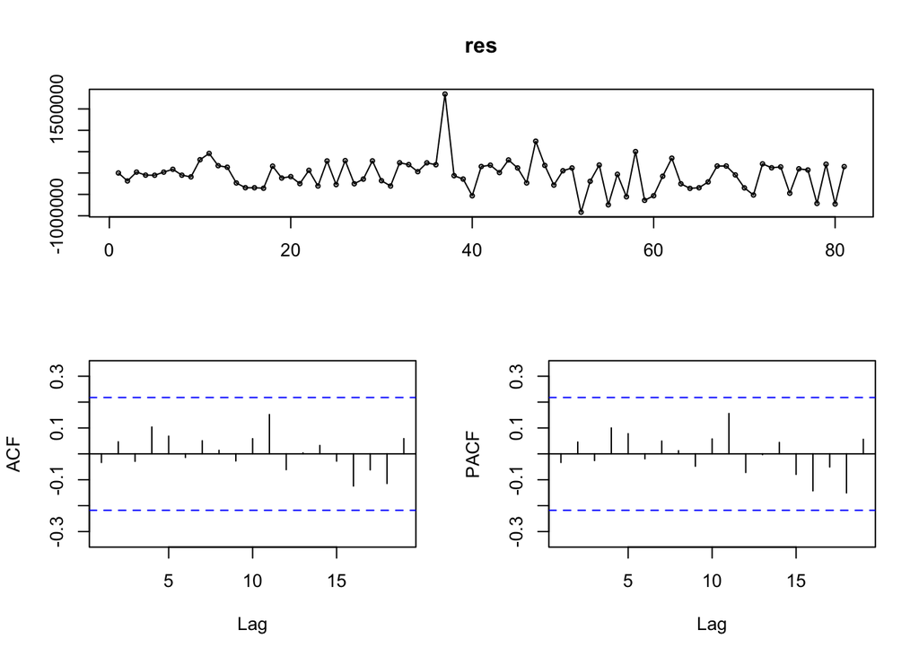

```r
res <- res[-c(1:12)]
tsdisplay(res)
```

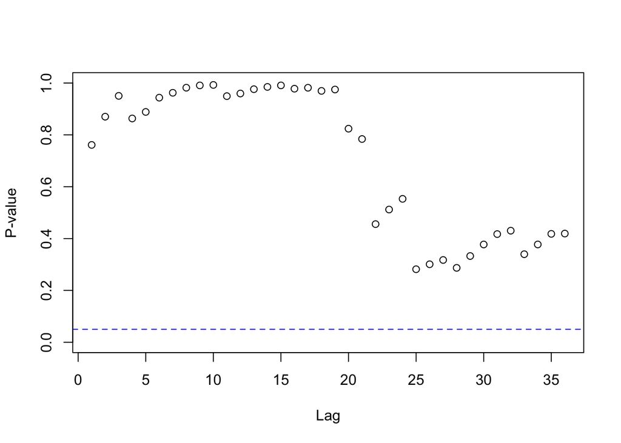

```r
p <- rep(0, 1, frequency(tSeries)*3)
for (i in 1:length(p)){
  p[i] <- Box.test(res, lag=i, type = "Ljung-Box")$p.value
}
plot(p, xlab="Lag", ylab="P-value", ylim=c(0,1))
abline(h = 0.05, lty = 2, col = "blue")
```

Q-Q plot и гистограмма:

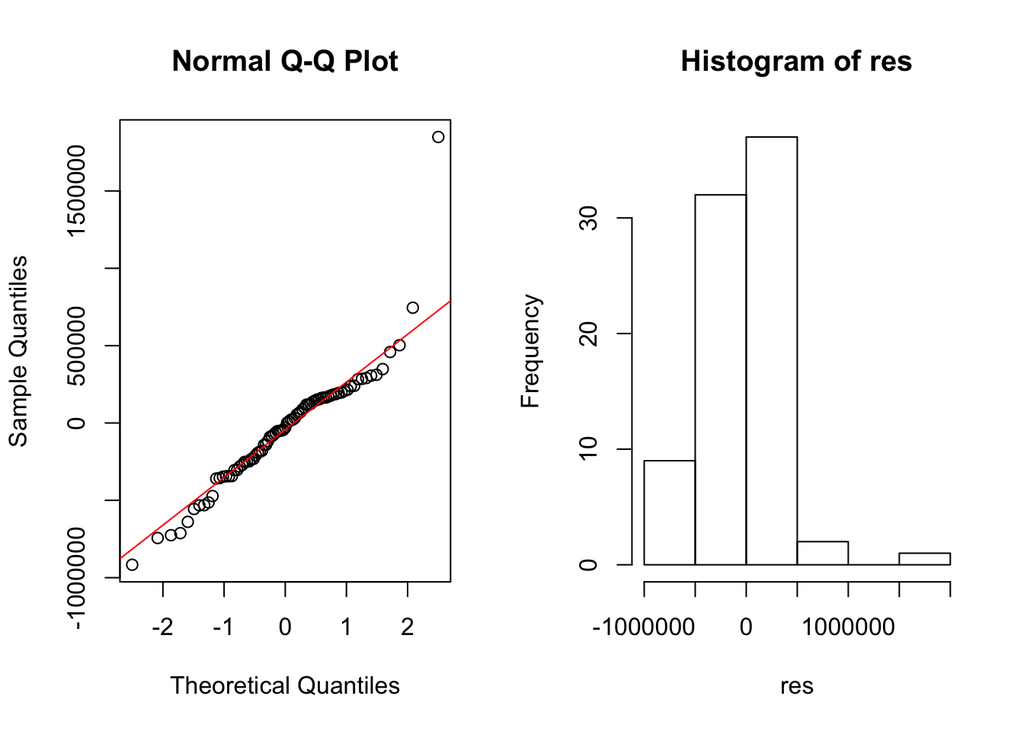

```r
par(mfrow=c(1,2))
qqnorm(res)
qqline(res, col="red")
hist(res)
```

# Сравниваем АРИМы

Сравним остатки двух версий аримы:

```r
fitted(fit.arima.auto)
```

[output not shown]

```r
res      <- tSeries - fitted(fit.arima.hand)
res.auto <- tSeries - fitted(fit.arima.auto)

fit.arima <- fit.arima.auto

fit.arima.auto$aic
```

```
## [1] 2292.906
```

```r
fit.arima.hand$aic
```

```
## [1] 2296.551
```

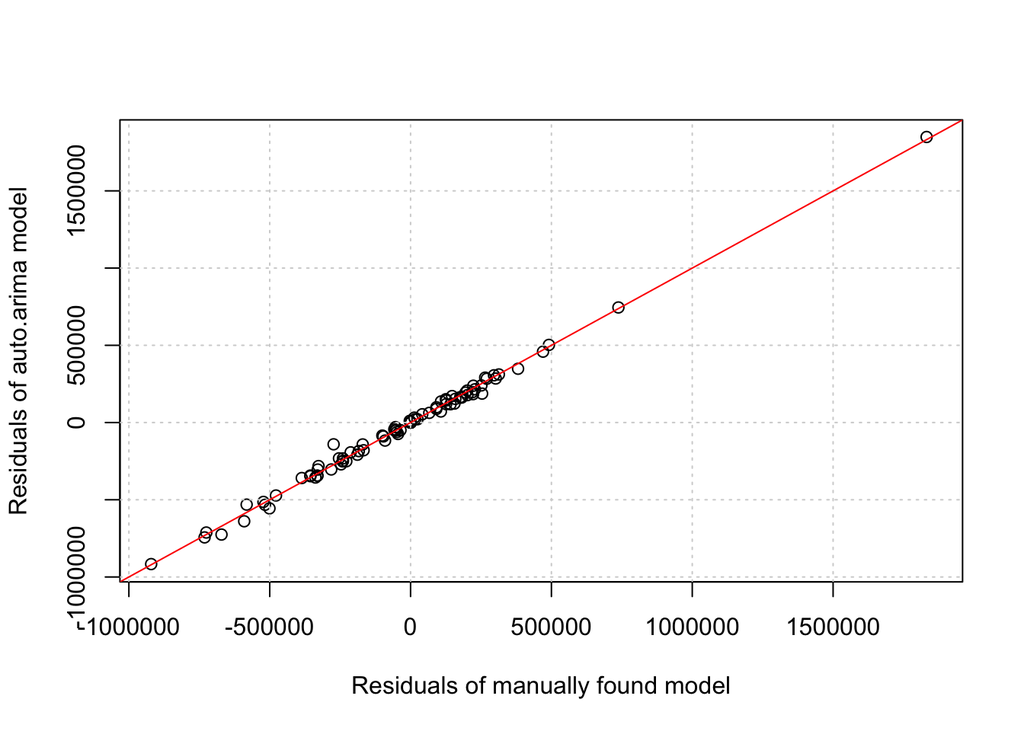

```r
plot(c(res), c(res.auto), xlim=c(min(res, res.auto), max(res, res.auto)), ylim=c(min(res, res.auto), max(res, res.auto)),
     xlab = "Residuals of manually found model", ylab="Residuals of auto.arima model")
grid()
lines(c(min(res, res.auto), max(res, res.auto))*2, c(min(res, res.auto), max(res, res.auto))*2, col="red")
```

```r
dm.test(res, res.auto)
```

```
##
##  Diebold-Mariano Test
##
## data:  resres.auto
## DM = -0.26335, Forecast horizon = 1, Loss function power = 2,
## p-value = 0.7929
## alternative hypothesis: two.sided
```

Критерий Диболда-Мариано не обнаруживает значимого различия между качеством прогнозов.

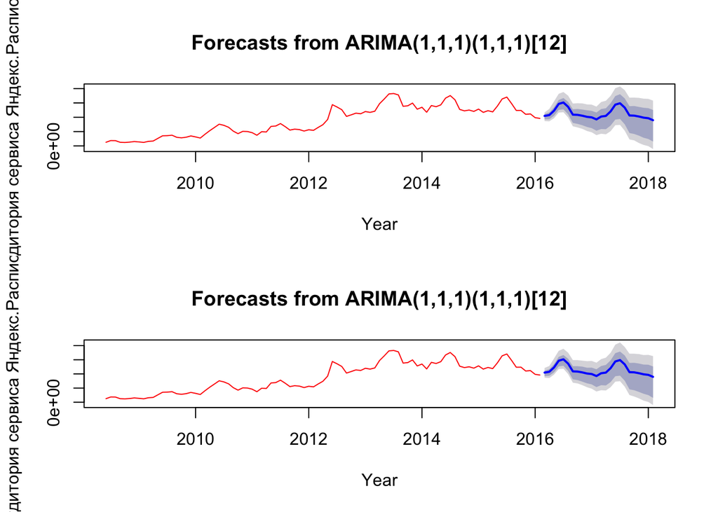

```r
fit.arima <- fit.arima.hand

par(mfrow=c(2,1))

D <- 24
fl <- forecast(fit.arima.hand, h=D, bootstrap=TRUE)
plot(fl, ylab=xname, xlab="Year", col="red")

fl <- forecast(fit.arima, h=D, bootstrap=TRUE)
plot(fl, ylab=xname, xlab="Year", col="red")
```

# ETS

```r
trainSeries <- window(tSeries, end=c(2014, 1))
testSeries  <- window(tSeries, start=c(2014,2))

fit.ets <- ets(tSeries, lambda=LambdaOpt)
print(fit.ets)
```

```
## ETS(A,A,A)
##
## Call:
##  ets(y = tSeries, lambda = LambdaOpt)
##
##   Box-Cox transformation: lambda= 1
##
##   Smoothing parameters:
##     alpha = 0.8221
##     beta  = 0.0264
##     gamma = 1e-04
##
##   Initial states:
##     l = -87162.145
##     b = 91746.7122
##     s=307336.8 -207449.2 -344344.4 -757274.8 -414790.5 -447114.5
##            -246515.1 -364887 -269194.9 667968.6 1092618 983646.6
##
##   sigma:  330267.6
##
##      AIC     AICc      BIC
## 2817.156 2824.314 2857.678
```

Настроив выбранную модель на обучающей выборке, посчитаем её качество на тестовой:

```r
fitShort <- ets(trainSeries, model="AAA", damped=F)
fc       <- forecast(fitShort, h=24)

accuracy(fc, testSeries)
```

```
##                       ME      RMSE       MAE         MPE     MAPE
## Training set    -2549.69  317106.7  216941.9  -0.6788034 12.54049
## Test set     -1546697.18 1804195.3 1554763.7 -31.2039834 31.34711
##                   MASE        ACF1 Theil's U
## Training set 0.1878859 0.001588094        NA
## Test set     1.3465275 0.792264452   3.38449
```

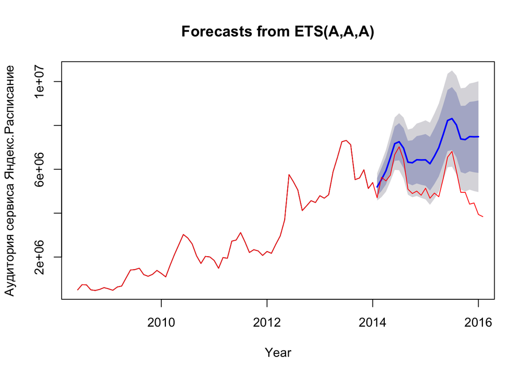

```r
plot(forecast(fitShort, h=D), ylab=xname, xlab="Year")
lines(tSeries, col="red")
```

Остатки:

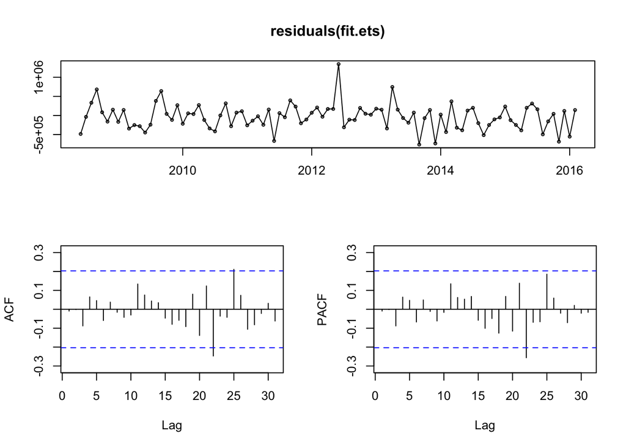

```r
tsdisplay(residuals(fit.ets))
```

Достигаемые уровни значимости критерия Льюнга-Бокса для них:

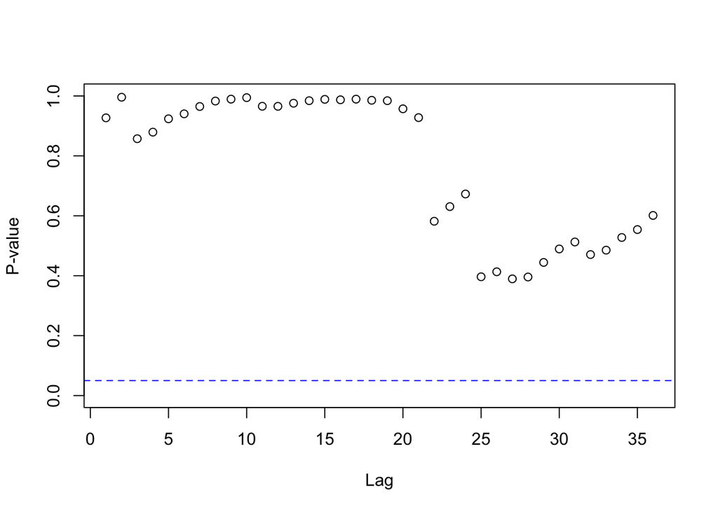

```r
p <- rep(0, 1, frequency(tSeries)*3)
for (i in 1:length(p)){
  p[i] <- Box.test(residuals(fit.ets), lag=i, type = "Ljung-Box")$p.value
}
plot(p, xlab="Lag", ylab="P-value", ylim=c(0,1))
abline(h = 0.05, lty = 2, col = "blue")
```

```r
res  <- tSeries - fitted(fit.arima)
res.ets  <- tSeries - fit.ets$fitted
```

# Итоговое сравнение

Сравним остатки лучших моделей ARIMA и ETS:

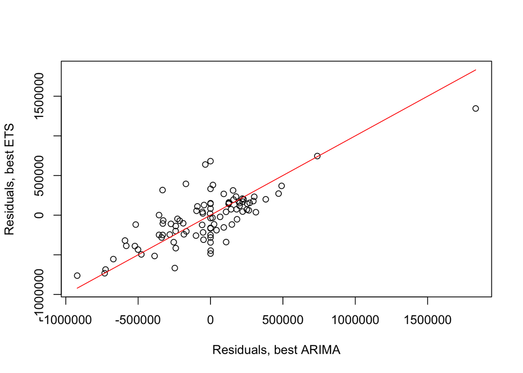

```r
plot(c(res), c(res.ets),
     xlab="Residuals, best ARIMA",
     ylab="Residuals, best ETS",
     xlim=c(min(c(res, res.ets), na.rm=T), max(c(res, res.ets), na.rm=T)),
     ylim=c(min(c(res, res.ets), na.rm=T), max(c(res, res.ets), na.rm=T)))
 lines(c(min(c(res, res.ets), na.rm=T), max(c(res, res.ets), na.rm=T)), c(min(c(res, res.ets), na.rm=T), max(c(res, res.ets), na.rm=T)), col="red")
```

```r
dm.test(res, res.ets)
```

```
##
##  Diebold-Mariano Test
##
## data:  resres.ets
## DM = 0.66135, Forecast horizon = 1, Loss function power = 2,
## p-value = 0.51
## alternative hypothesis: two.sided
```

```r
fit.arima$aic
```

```
## [1] 2296.551
```

```r
fit.ets$aic
```

```
## [1] 2817.156
```

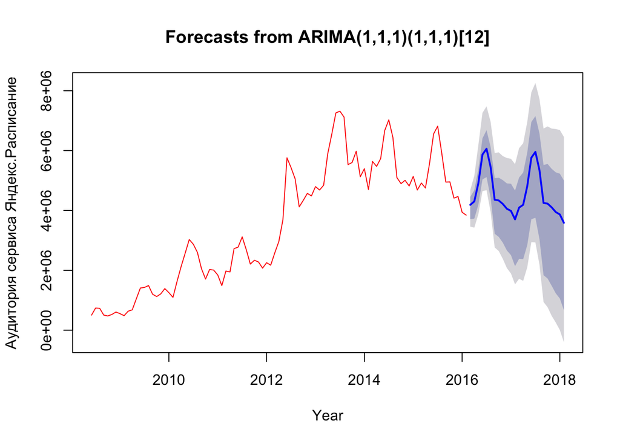

```r
D <- 24
if (fit.arima$aic < fit.ets$aic ) {
  fl <- forecast(fit.arima, h=D, bootstrap=TRUE)

  plot(fl, ylab=xname, xlab="Year", col="red")
} else {
  fl <- forecast(fit.ets, h=D, bootstrap=TRUE)
  plot(fl, ylab=xname, xlab="Year", col="red")
}
```